# Aula 2

## Base de Dados

Sérgio Daneris

**Referências:**

- THE PANDAS DEVELOPMENT TEAM. pandas-dev/pandas: Pandas. Version latest. Zenodo, fev. 2020. Disponível em: https://doi.org/10.5281/zenodo.3509134. https://pandas.pydata.org/
- HARRIS, C. R. et al. Array programming with NumPy. Nature, v. 585, n. 7825, p. 357–362, 2020. Disponível em: https://doi.org/10.1038/s41586-020-2649-2
- HUNTER, J. D. Matplotlib: A 2D graphics environment. Computing in Science & Engineering, v. 9, n. 3, p. 90–95, 2007. IEEE Computer Society. Disponível em: https://doi.org/10.1109/MCSE.2007.55. https://matplotlib.org/stable/

Etapa de Prática

*Carregando as bibliotecas*

```python
import pandas as pd # Leitura e manipulação de base de dados
import numpy as np # Operações matemáticas
```

**Base de dados**

A base de dados utilizada no exemplo vai ser a *BWGTH*.

**Variáveis:**

faminc: renda familiar em 1988, em milhares de dólares

cigtax: imposto sobre cigarros no estado de residência, 1988

cigprice: preço do cigarro no estado de residência, 1988

bwght: peso ao nascer, em onças

fatheduc: anos de escolaridade do pai

motheduc: anos de escolaridade da mãe

parity: ordem de nascimento da criança

male: =1 se for menino

white: =1 se for branco

cigs: cigarros fumados por dia durante a gravidez

lbwght: logaritmo do peso ao nascer

bwghtlbs: peso ao nascer, libras

packs: maços fumados por dia durante a gravidez

lfaminc: log(faminc) ##

Carregando a base de dados

```python
basededados1 = pd.read_csv('C:/Users/sergi/Desktop/Monitoria/bwght.csv') # Observações: As barras precisam estar assim /
```

- Usando a função print() (serve para visualizar informações da base de dados).

Head () - Mostrar as primeiras linhas da base

```python
print(basededados1.head())
```

```
   faminc  cigtax    cigprice  bwght  fatheduc  motheduc  parity  male  white  \
0    13.5    16.5  122.300003    109      12.0      12.0       1     1      1
1     7.5    16.5  122.300003    133       6.0      12.0       2     1      0
2     0.5    16.5  122.300003    129       NaN      12.0       2     0      0
3    15.5    16.5  122.300003    126      12.0      12.0       2     1      0
4    27.5    16.5  122.300003    134      14.0      12.0       2     1      1

   cigs    lbwght  bwghtlbs  packs   lfaminc
0     0  4.691348    6.8125    0.0  2.602690
1     0  4.890349    8.3125    0.0  2.014903
2     0  4.859812    8.0625    0.0 -0.693147
3     0  4.836282    7.8750    0.0  2.740840
4     0  4.897840    8.3750    0.0  3.314186
```

Tail () - Mostrar as últimas linhas da base

```python
print(basededados1.tail())
```

```
      faminc  cigtax    cigprice  bwght  fatheduc  motheduc  parity  male  \
1383    27.5    30.0  138.300003    110      12.0      12.0       4     1
1384     5.5    30.0  138.300003    146       NaN      16.0       2     1
1385    65.0     8.0  118.599998    135      18.0      16.0       2     0
1386    27.5     8.0  118.599998    118       NaN      14.0       2     0
1387    37.5     8.0  118.599998    111      16.0      13.0       2     0

      white  cigs    lbwght  bwghtlbs  packs   lfaminc
1383      1     0  4.700480    6.8750    0.0  3.314186
1384      1     0  4.983607    9.1250    0.0  1.704748
1385      1     0  4.905275    8.4375    0.0  4.174387
1386      1     0  4.770685    7.3750    0.0  3.314186
1387      1     0  4.709530    6.9375    0.0  3.624341
```

Shape - Mostrar o número de linhas e colunas (linhas, colunas)

```python
print(basededados1.shape)
```

```
(1388, 14)
```

Columns - Mostrar o nome das colunas (Variáveis)

```python
print(list(basededados1.columns))
```

```
['faminc', 'cigtax', 'cigprice', 'bwght', 'fatheduc', 'motheduc', 'parity', 'male', 'white', 'cigs', 'lbwght', 'bwghtlbs', 'packs', 'lfaminc']
```

- Manipulando a base de dados

Trocando o nome da variável ¨faminc¨ por renda_familiar

```python
basededados1 = basededados1.rename(columns={'faminc': 'renda_familiar'})
```

```python
print(basededados1.columns)
```

```
Index(['renda_familiar', 'cigtax', 'cigprice', 'bwght', 'fatheduc', 'motheduc',
       'parity', 'male', 'white', 'cigs', 'lbwght', 'bwghtlbs', 'packs',
       'lfaminc'],
      dtype='object')
```

- Criando variáveis

Variável Dummy para baixo peso ao nascer

```python
# Critério:
# Peso ao nascer menor que 5.5 libras

basededados1["baixo_peso"] = (basededados1["bwghtlbs"] < 5.5).astype(int)

# Visualizando a variável criada
print(basededados1["baixo_peso"].head(50))
```

```
0     0
1     0
2     0
3     0
4     0
5     0
6     0
7     1
8     0
9     0
10    0
11    0
12    1
13    0
14    0
```

[output cut: 36 more lines]

```python
basededados1["fumante_intensa"] = (basededados1["cigs"] > 25).astype(int)

# Visualizando a variável
print(basededados1["fumante_intensa"].head(50))
```

```
0     0
1     0
2     0
3     0
4     0
5     0
6     0
7     0
8     0
9     0
10    0
11    0
12    0
13    0
14    0
```

[output cut: 36 more lines]

Criando a variável com peso ao nascer em quilogramas

```python
# Convertendo peso ao nascer de libras para quilogramas

basededados1["peso_kg"] = (basededados1["bwghtlbs"] * 0.453592)

# Visualizando a variável
print(basededados1["peso_kg"].head(50))
```

```
0     3.090095
1     3.770484
2     3.657085
3     3.572037
4     3.798833
5     3.345241
6     3.968930
7     2.438057
8     3.430289
9     3.657085
10    2.863300
11    3.770484
12    1.729319
13    2.948348
14    2.608154
```

[output cut: 36 more lines]

- Remover Coluna

```python
# Removendo a coluna "packs"

basededados1 = basededados1.drop(columns=["packs"])

# Visualizando as colunas restantes
print(basededados1.columns)
```

```
Index(['renda_familiar', 'cigtax', 'cigprice', 'bwght', 'fatheduc', 'motheduc',
       'parity', 'male', 'white', 'cigs', 'lbwght', 'bwghtlbs', 'lfaminc',
       'baixo_peso', 'fumante_intensa', 'peso_kg'],
      dtype='object')
```

Remover linhas com NAN

Contar os valores ausentes antes de remover

```python
# Contando quantidade de NA por coluna

print(basededados1.isnull().sum())
```

[output not shown]

```python
# Removendo linhas com valores ausentes (NA)

basededados1 = basededados1.dropna()

# Verificando a base
print(basededados1.info())
```

[output not shown]

Calculando a média de uma variável

```python
# Calculando a média da renda familiar, a média representa o valor médio da renda familiar.

print(basededados1["faminc"].mean())
```

[output not shown]

Calculando a mediana

```python
# Calculando a mediana do peso ao nascer

print(basededados1["bwghtlbs"].median())
```

```
7.5
```

- Gráficos

A biblioteca Matplotlib é uma das principais ferramentas do Python para criação de gráficos e visualizações de dados. Ela permite transformar informações numéricas em gráficos de forma visual e intuitiva, facilitando a análise e interpretação dos dados.

**pyplot é o módulo responsável por criar e controlar gráficos de forma simples e parecida com o funcionamento do MATLAB**

```python
import matplotlib.pyplot as plt
```

Histograma - Mostra a Distribuição da Variável

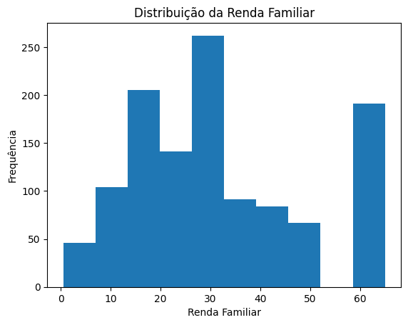

```python
# Criando histograma

plt.hist(basededados1["faminc"])

# Título do gráfico
plt.title("Distribuição da Renda Familiar")

# Nome eixo X
plt.xlabel("Renda Familiar")

# Nome eixo Y
plt.ylabel("Frequência")

# Exibindo gráfico
plt.show()
```

Boxplot

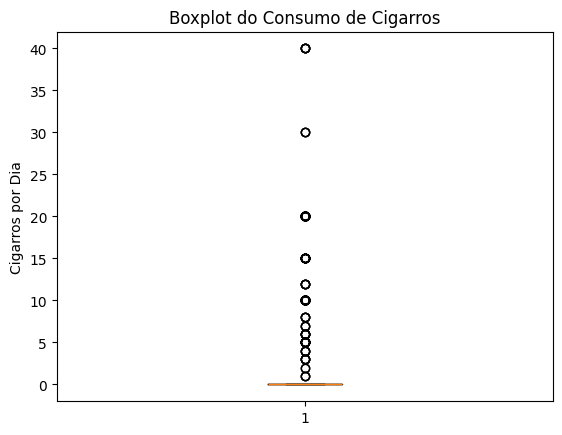

```python
# Boxplot do consumo de cigarros

plt.boxplot(basededados1["cigs"])

plt.title("Boxplot do Consumo de Cigarros")

plt.ylabel("Cigarros por Dia")

plt.show()
```

Dispersão entre renda e peso ao nascer

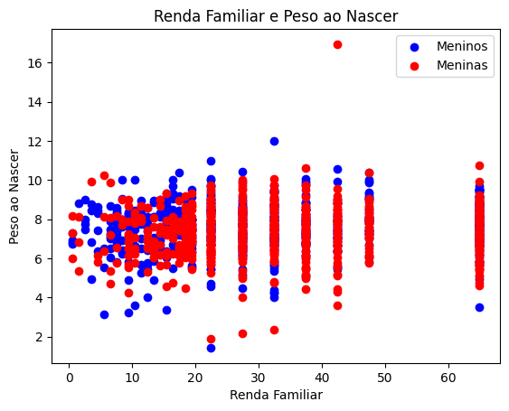

```python
# Separando observações

homens = basededados1[basededados1["male"] == 1]

mulheres = basededados1[basededados1["male"] == 0]

# Criando scatterplot

plt.scatter(homens["faminc"],homens["bwghtlbs"],
    color="blue",
    label="Meninos")

plt.scatter(mulheres["faminc"],mulheres["bwghtlbs"],
    color="red",
    label="Meninas")

plt.title("Renda Familiar e Peso ao Nascer")

plt.xlabel("Renda Familiar")

plt.ylabel("Peso ao Nascer")

# Mostrar legenda

plt.legend()

# Exibir gráfico

plt.show()
```

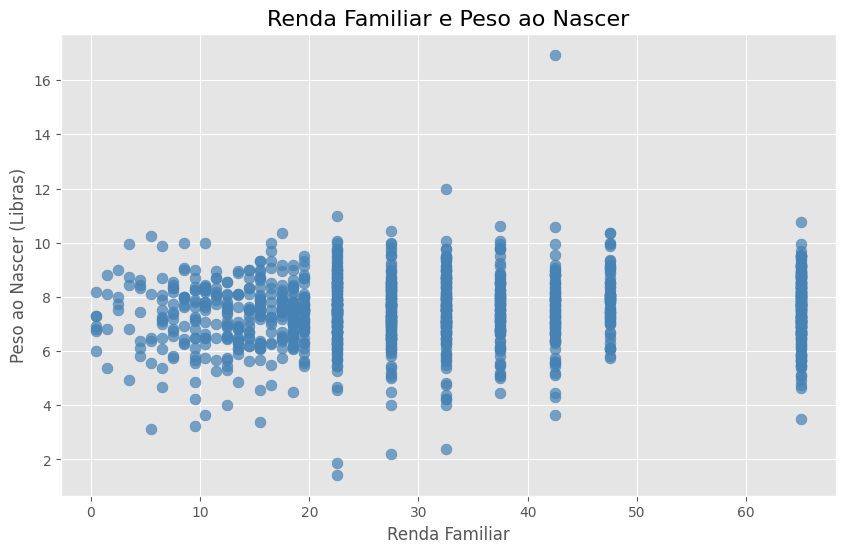

```python
# Estilo ggplot
plt.style.use('ggplot')

# Criando figura e eixo
fig, ax = plt.subplots(figsize=(10,6))

# Scatterplot
ax.scatter(
    basededados1["faminc"],
    basededados1["bwghtlbs"],
    color="steelblue",
    alpha=0.7,
    s=60)

# Título
ax.set_title("Renda Familiar e Peso ao Nascer",fontsize=16)

# Nome dos eixos
ax.set_xlabel("Renda Familiar",fontsize=12)

ax.set_ylabel("Peso ao Nascer (Libras)",fontsize=12)

# Grid
ax.grid(True)

# Mostrar gráfico
plt.show()
```

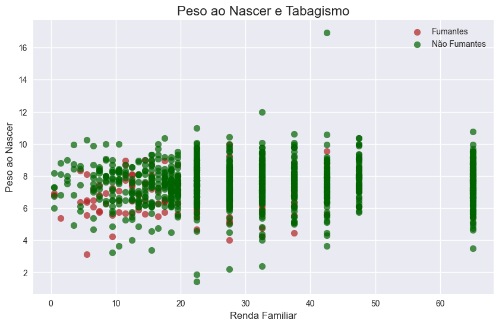

```python
# Estilo seaborn
plt.style.use('seaborn-v0_8')

# Separando grupos
fumantes = basededados1[basededados1["cigs"] > 0]

nao_fumantes = basededados1[basededados1["cigs"] == 0]

# Figura
fig, ax = plt.subplots(figsize=(10,6))

# Grupo fumantes
ax.scatter(
    fumantes["faminc"],
    fumantes["bwghtlbs"],
    color="firebrick",
    label="Fumantes",
    alpha=0.7,
    s=60)

# Grupo não fumantes
ax.scatter(
    nao_fumantes["faminc"],
    nao_fumantes["bwghtlbs"],
    color="darkgreen",
    label="Não Fumantes",
    alpha=0.7,
    s=60)

# Título
ax.set_title("Peso ao Nascer e Tabagismo",fontsize=16)

# Eixos
ax.set_xlabel("Renda Familiar", fontsize=12)

ax.set_ylabel("Peso ao Nascer", fontsize=12)

# Legenda
ax.legend()

# Grid
ax.grid(True)

# Mostrar gráfico
plt.show()
```

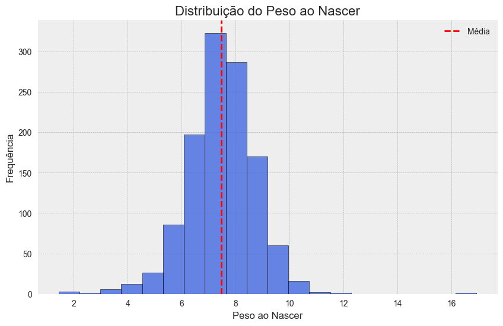

```python
# Estilo bmh
plt.style.use('bmh')

# Figura
fig, ax = plt.subplots(figsize=(10,6))

# Histograma
ax.hist(basededados1["bwghtlbs"],
    bins=20,
    color="royalblue",
    edgecolor="black",
    alpha=0.8)

# Linha da média
ax.axvline(basededados1["bwghtlbs"].mean(),
    color="red",
    linestyle="--",
    linewidth=2,
    label="Média")

# Título
ax.set_title("Distribuição do Peso ao Nascer",fontsize=16)

# Eixos
ax.set_xlabel("Peso ao Nascer", fontsize=12)

ax.set_ylabel("Frequência", fontsize=12)

# Legenda
ax.legend()

# Mostrar gráfico
plt.show()
```

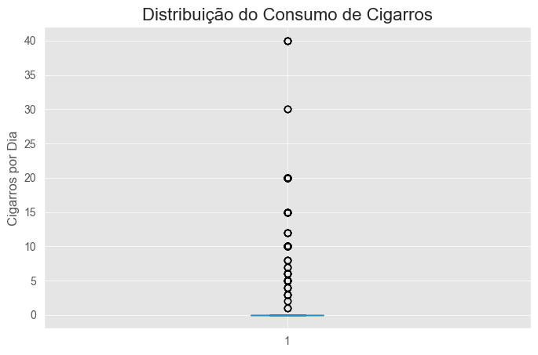

```python
# Estilo ggplot
plt.style.use('ggplot')

# Figura
fig, ax = plt.subplots(figsize=(8,5))

# Boxplot
ax.boxplot(basededados1["cigs"],patch_artist=True)

# Título
ax.set_title("Distribuição do Consumo de Cigarros",fontsize=16)

# Eixo Y
ax.set_ylabel("Cigarros por Dia",fontsize=12)

# Mostrar gráfico
plt.show()
```